# RaportPD3

Franciszek Filipek

2023-03-27

# Słupki czy kąty

W swojej pracy postanowiłem sprawdzić, jaki typ wykresu jest bardziej czytelny; słupkowy bądź kołowy, więc przygotowałem cztery wykresy bazujace na ramce danych auta2012.

## Pytanie nr 1

Który z poniższych wykresów jest czytelniejszy?

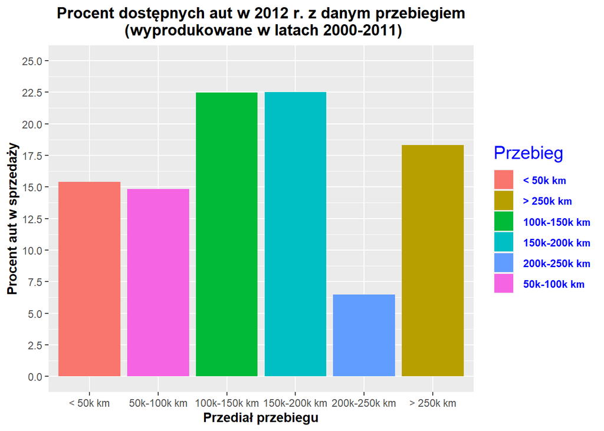

```r
auta2012 %>%
  filter(Rok.produkcji >= 2000) %>%
  mutate(Przebieg = case_when(Przebieg.w.km < 50000 ~ "< 50k km", Przebieg.w.km >= 50000 & Przebieg.w.km < 100000 ~ "50k-100k km",
                              Przebieg.w.km >= 100000 & Przebieg.w.km < 150000 ~ "100k-150k km", Przebieg.w.km >= 150000
                              & Przebieg.w.km < 200000 ~ "150k-200k km",
                              Przebieg.w.km >= 200000 & Przebieg.w.km <= 250000 ~ "200k-250k km", TRUE ~ "> 250k km")) %>%
  group_by(Przebieg) %>%
  summarise(n = n()) %>%
  mutate(Procent = (n/sum(n))*100) %>%
  ggplot(aes(x = factor(Przebieg, levels = c("< 50k km", "50k-100k km", "100k-150k km", "150k-200k km", "200k-250k km", "> 250k km")), y = Procent, fill = Przebieg)) +
  geom_col() +
  labs(title = "Procent dostępnych aut w 2012 r. z danym przebiegiem\n (wyprodukowane w latach 2000-2011)", x = "Przediał przebiegu", y = "Procent aut w sprzedaży") +
  theme(plot.title = element_text(hjust = 0.5, face = "bold")) +
  theme(legend.title = element_text(color = "blue", size = 15),
        legend.text = element_text(color = "blue", face = "bold"),
        axis.title = element_text(face = "bold")) +
  scale_y_continuous(n.breaks = 12, limits = c(0, 25))
```

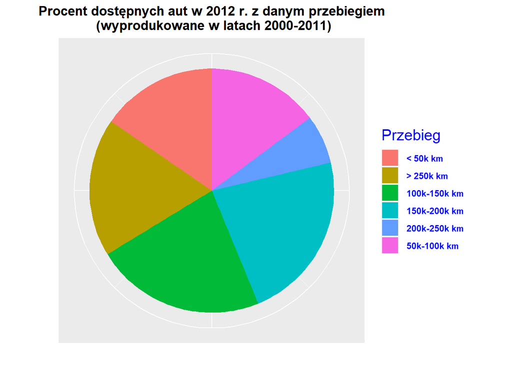

```r
ggplot(tmp, aes(x = "", y = Procent, fill = Przebieg)) +
  geom_col(width = 1) +
  coord_polar("y", start = 0) +
  labs(title = "Procent dostępnych aut w 2012 r. z danym przebiegiem\n (wyprodukowane w latach 2000-2011)",
       y = "", x = "") +
  theme(plot.title = element_text(hjust = 0.5, face = "bold")) +
  theme(legend.title = element_text(color = "blue", size = 15),
        legend.text = element_text(color = "blue", face = "bold"),
        axis.ticks=element_blank(), axis.text = element_blank()) +
  labs(fill='Przebieg')
```

## Pytanie nr 2

Pytanie jest takie samo jak poprzednie, lecz wykresy są nieco inne. Obydwa posiadają dodatkowe dopiski informujące o udziale procentowym aut z danego przedziału przebiegu. (Odpowiednio na słupkach/ na wycinkach)

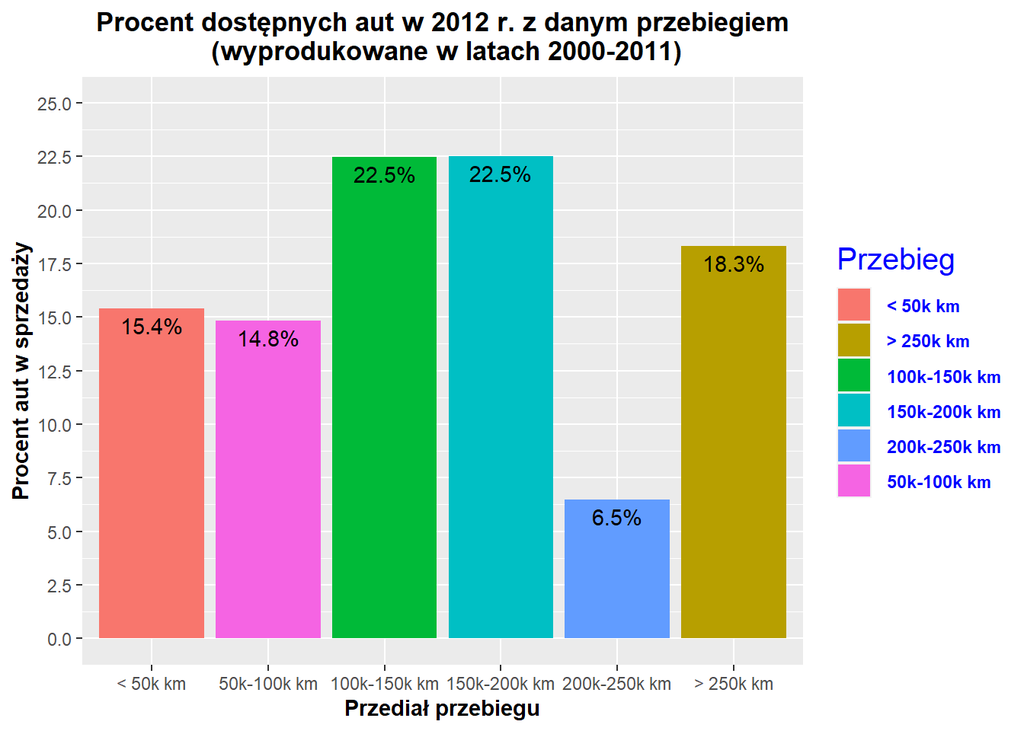

```r
auta2012 %>%
  filter(Rok.produkcji >= 2000) %>%
  mutate(Przebieg = case_when(Przebieg.w.km < 50000 ~ "< 50k km", Przebieg.w.km >= 50000 & Przebieg.w.km < 100000 ~ "50k-100k km",
                              Przebieg.w.km >= 100000 & Przebieg.w.km < 150000 ~ "100k-150k km", Przebieg.w.km >= 150000
                              & Przebieg.w.km < 200000 ~ "150k-200k km",
                              Przebieg.w.km >= 200000 & Przebieg.w.km <= 250000 ~ "200k-250k km", TRUE ~ "> 250k km")) %>%
  group_by(Przebieg) %>%
  summarise(n = n()) %>%
  mutate(Procent = (n/sum(n))*100) %>%
  ggplot(aes(x = factor(Przebieg, levels = c("< 50k km", "50k-100k km", "100k-150k km", "150k-200k km", "200k-250k km", "> 250k km")), y = Procent, fill = Przebieg)) +
  geom_col() +
  labs(title = "Procent dostępnych aut w 2012 r. z danym przebiegiem\n (wyprodukowane w latach 2000-2011)", x = "Przediał przebiegu", y = "Procent aut w sprzedaży") +
  theme(plot.title = element_text(hjust = 0.5, face = "bold")) +
  theme(legend.title = element_text(color = "blue", size = 15),
        legend.text = element_text(color = "blue", face = "bold"),
        axis.title = element_text(face = "bold")) +
  scale_y_continuous(n.breaks = 12, limits = c(0, 25)) +
  geom_text(aes(label = paste0(round(Procent,1), "%")),colour = "black", vjust = 1.5)
```

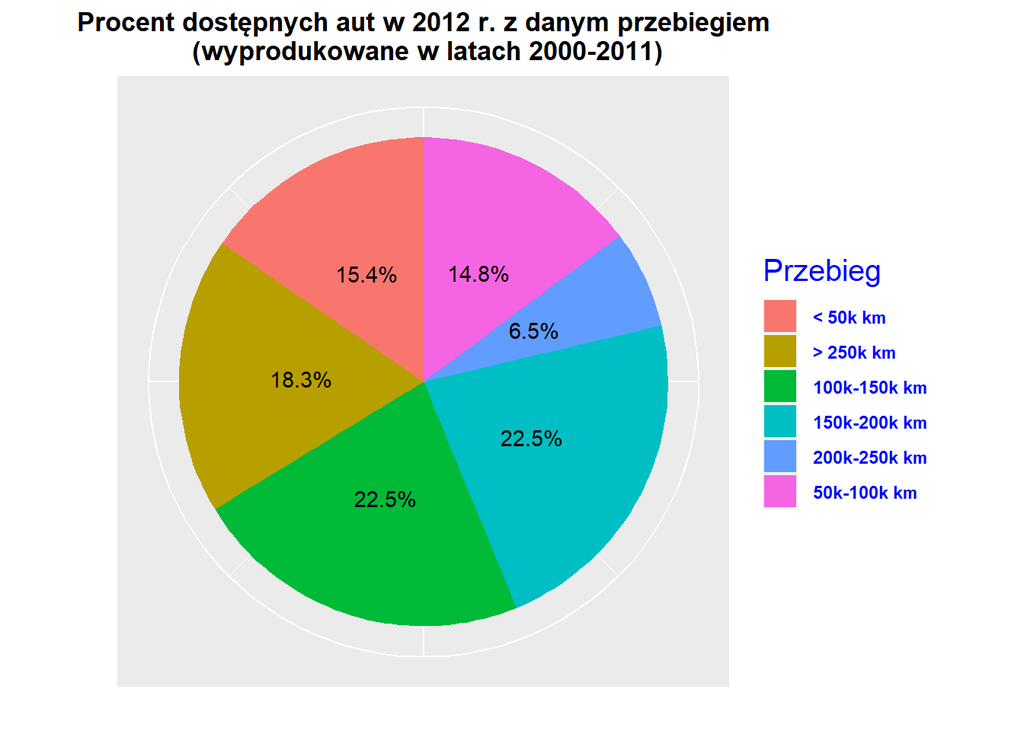

```r
ggplot(tmp, aes(x = "", y = Procent, fill = Przebieg)) +
  geom_col(width = 1) +
  coord_polar("y", start = 0) +
  labs(title = "Procent dostępnych aut w 2012 r. z danym przebiegiem\n (wyprodukowane w latach 2000-2011)",
       y = "", x = "") +
  theme(plot.title = element_text(hjust = 0.5, face = "bold")) +
  theme(legend.title = element_text(color = "blue", size = 15),
        legend.text = element_text(color = "blue", face = "bold"),
        axis.ticks=element_blank(), axis.text = element_blank()) +
  labs(fill='Przebieg') +
  geom_text(aes(label = paste0(round(Procent,1), "%")),
            position = position_stack(vjust = 0.5))
```

## Pytanie nr 3

Jakie wykresy zazwyczaj preferujesz? (Odpowiedzi: Kołowe, Słupkowe, Nie mam zdania)

## Wyniki ankiety

W ankiecie wzięło udział 17 osób. W pytaniu nr 1, 8 osób wybrało wykres kołowy, pozostałe 9 zaś słupkowy. Wykres słupkowy “wygrał” uzyskując wynik 53%. W pytaniu nr 2, gdzie dodane zostały dodatkowe dopiski procentów dla poszczególnych słupków/wycinków, na wykres kołowy zagłosowało aż 10 osób, pozostałe 7 wybrały wykres słupkowy. Wykres kołowy wygrał uzyskując wynik około 60%. W pytaniu 3 (ogólnym), 9 osób wybrało wykres słupkowy, 4 osoby kołowy a pozostałe 4 osoby nie mają zdania. Wizualizacją wyników i podsumowanie poniżej.

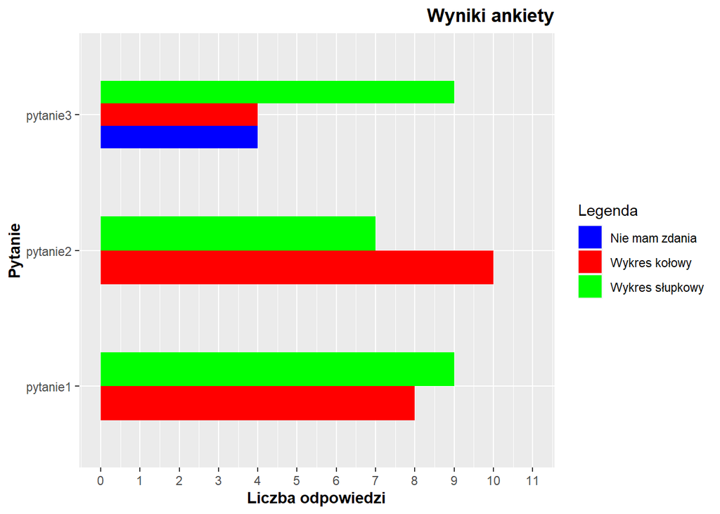

```r
wyniki2 %>%
  group_by(Pytanie, Odpowiedz) %>%
  summarise(n = n()) %>%
  ungroup() %>%
  ggplot(aes(x = Pytanie, y = n, fill = factor(Odpowiedz))) +
  geom_col(position = "dodge", width = 0.5) +
  scale_fill_manual(values = c("blue", "red", "green")) +
  coord_flip() +
  labs(x = "Pytanie",
       y = "Liczba odpowiedzi",
       fill = "Legenda",
       title = "Wyniki ankiety") +
  theme(plot.title = element_text(hjust = 1, face = "bold"), axis.title = element_text(face = "bold")) +
  scale_y_continuous(n.breaks = 12, limits = c(0, 11))
```

## Podsumowanie

Pomimo lepszej jakości wykresu słupkowego, wykres kołowy ma sporą popularność, zwłaszcza z dodatkowymi dopiskami procentowymi na wycinkach. Prawdopodobnie wynika to z ich masowego użycia w mediach i oraz ciekawego, przyciągającego oko wyglądu. Jednakże w pytaniu ogólnym (nr 3), wykres słupkowy wygrał z ogromną przewagą, gdyż wykresowi słupkowemu nie można odmówić przejrzystości i czytelności zwłaszcza przy analizie czegoś nieco bardziej złożonego od wyników wyborów.